# **EDA on YouTube data**. - Python Project WK03

# **Infrances:**

- The video with the title "Cuties | Official Trailer | Netflix" has received the maximum number of dislikes. This suggests that the content of the video might have been controversial or offensive to some viewers, leading to a high number of dislikes.
- The video with the title "Tims For Good: A Taste Of The Familiar" has received the minimum number of dislikes. This suggests that the content of the video was well-received by viewers, or that the video did not generate much attention, leading to a low number of dislikes.

**13. Does the number of views have any effect on how many people disliked the video? Support your answer with a metric and a plot.**

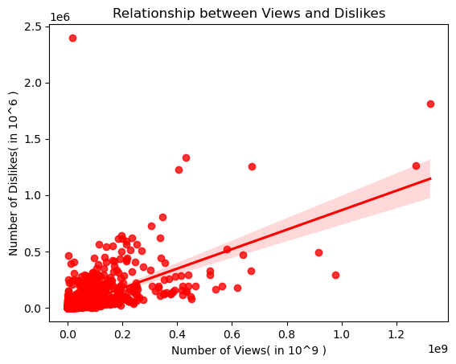

```
Correlation coefficient between views and dislikes: 0.6845758297072607
```

```python
# scatterplot between views and dislikes
sns.regplot(data=df, x=df['view_count'], y=df['dislikes'], color='red')
plt.title('Relationship between Views and Dislikes')
plt.xlabel('Number of Views( in 10^9 )')
plt.ylabel('Number of Dislikes( in 10^6 )')
plt.show()

# Calculate the correlation coefficient between views and dislikes
corr_coef = df['view_count'].corr(df['dislikes'])

# Print the correlation coefficient
print(f"Correlation coefficient between views and dislikes: {corr_coef}")
```

- Based on the correlation coefficient of 0.6846 and the scatter plot, we can interpret that there is a moderate positive correlation between the number of views and the number of dislikes, but the relationship is not perfectly linear.
- The scatter plot suggests that as the number of views increases, the number of dislikes tends to increase as well, but the rate of increase is not evidently constant across all levels of views.

**14. Display all the information about the videos that were published in January, and mention the count of videos that were published in January.**

```python
# Filter the DataFrame to only include videos published in January
january_videos = df[df['published_month'] == 'Jan']

# Display information about the January videos
display(january_videos)

# Print the count of videos published in January
print(f"{len(january_videos)} videos were published in January")
```

|  | video_id | title | channel_id | channel_title | published_at | view_count | likes | dislikes | comment_count | tags | description | comments | published_month |
| --- | --- | --- | --- | --- | --- | --- | --- | --- | --- | --- | --- | --- | --- |
| 27 | -2Gwm7QfBnE | Q&A With Naisha | UCYwNMbogQFzMccPSuy-pPWg | MianTwins | 2021-01-21 00:05:47 | 872372 | 38626 | 239 | 621 |  | Hey Guys!!! this has been the most requested v... | I feel like Nate and Aishas personality match ... | Jan |
| 48 | -4sfXSHSxzA | SURPRISING BRENT WITH HIS TIKTOK CRUSH!! | UCPpATKqmMV-CNRNWYaDUwiA | Alexa Rivera | 2021-01-16 21:40:04 | 6504784 | 262477 | 5779 | 7907 |  | He had no idea! Thank you guys so much for wat... | Thank you guys for watching and don't forget t... | Jan |
| 95 | -AJD1Fc5rpQ | WE ARE HAVING A BABY! \| finding out i'm pregna... | UCVsTboAhpnuL6j-tDePvNwQ | Tess Christine | 2021-01-03 21:53:48 | 533084 | 38965 | 119 | 1650 |  | I am so happy to tell you that I am pregnant!!... | Okay I needed a moment to collect my thoughts ... | Jan |
| 103 | -AuJiwjsmWk | Do Ugly Foods Taste Worse? Taste Test | UCzpCc5n9hqiVC7HhPwcIKEg | Good Mythical MORE | 2021-01-19 11:00:01 | 1057077 | 22526 | 531 | 773 | gmm good mythical morning rhettandlink rhett a... | Today, we're doing a blind taste test to deter... | "there's nothing wrong with it being bent"\nI ... | Jan |
| 182 | -JhqO2KWr5U | Schlatt gets fit | UCWZp4y1jqBuvLtiyxSs_ZBw | Big guy | 2021-01-24 22:50:57 | 1724965 | 119431 | 325 | 1578 | jschlatt big guy jschlatt highlights schlatt j... | #jschlatt #schlatt #bigguy #short | Schlatt is single handedly wiping out all the ... | Jan |
| ... | ... | ... | ... | ... | ... | ... | ... | ... | ... | ... | ... | ... | ... |
| 37300 | zmzFL5bG-jc | DEVINE MON PERSONNAGE AVANT AKINATOR ! (c'est ... | UCIlr3byh6wmXgcPx_Tm9Ocw | Piwerre | 2021-01-16 16:12:19 | 670357 | 54462 | 832 | 1249 | Piwerre frere de michou crouton among us devin... | Discord Piwerre : https://discord.gg/QBduPgAA... | Mdr michou quand c'est pas ses tournage il fou... | Jan |
| 37329 | zpzjex7qwrA | Lampard Sacked Within Days Rorys Misery \| Chel... | UCkD-ZOixI0a9FjIExDsHsbg | The Kick Off | 2021-01-03 20:13:49 | 428646 | 12060 | 296 | 1505 | Premier league Chelsea chelsea 1-3 Man City Ch... | The Kick Off watched Manchester City destroy C... | True Its like a fighter who Geordie But I thou... | Jan |
| 37345 | zqyv-B6mnBM | Lil Wayne - Ain't Got Time (Audio) | UCO9zJy7HWrIS3ojB4Lr7Yqw | Lil Wayne | 2021-01-21 05:00:10 | 2238244 | 58925 | 2365 | 5539 | lil wayne weezy weezy wednesday wayne carter y... | Official audio for Lil Wayne "Ain't Got Time",... | RIP Juice Wrld, wrote that on two cups, pour o... | Jan |
| 37383 | zwfu1-24T7Q | PRADA Cup Day 1 \| Full Race Replay \| PRADA Cup... | UCo15ZYO_XDRU9LI30OPtxAg | America's Cup | 2021-01-15 04:07:55 | 317382 | 2008 | 83 | 192 | America's Cup Americas Cup AC36 AC75 Presented... | The opening day of the PRADA Cup in Auckland, ... | Incredible how these boats evolve in a short t... | Jan |
| 37418 | zziBybeSAtw | PELICANS at LAKERS \| FULL GAME HIGHLIGHTS \| Ja... | UCWJ2lWNubArHWmf3FIHbfcQ | NBA | 2021-01-16 05:39:05 | 2841917 | 20759 | 1049 | 2624 | NBA G League Basketball game-0022000187 Lakers... | PELICANS at LAKERS \| FULL GAME HIGHLIGHTS \| Ja... | Montrezl Harrell is going crazy with the rebou... | Jan |

2099 rows × 13 columns

```
2099 videos were published in January
```